# Class Activity, August 22

In this activity, you will start to investigate the relationship between wife’s age and contraceptive use, using data from the National Indonesia Contraceptive Prevalence Survey.

# Part I

One way to examine the relationship between age and contraceptive use is with a table:

| Age | Contraceptive use = 0 | Contraceptive use = 1 | Total |
| --- | --- | --- | --- |
| 20 | 17 | 11 | 28 |
| 21 | 19 | 29 | 48 |
| 22 | 27 | 32 | 59 |
| 23 | 21 | 23 | 44 |
| 24 | 24 | 37 | 61 |
| 25 | 33 | 47 | 80 |
| 26 | 27 | 42 | 69 |
| 27 | 23 | 36 | 59 |
| 28 | 27 | 36 | 63 |
| 29 | 18 | 41 | 59 |
| 30 | 23 | 41 | 64 |
| 31 | 20 | 26 | 46 |
| 32 | 21 | 43 | 64 |
| 33 | 16 | 39 | 55 |
| 34 | 17 | 33 | 50 |
| 35 | 17 | 45 | 62 |
| **Total** | 350 | 561 | 911 |

I say *empirical* probability here because we are estimating it from the observed data.

1. What is the (empirical) probability that a couple will use some contraception?
2. What is the (empirical) probability that a couple will use some contraception, given that the wife is 20 years old? What about if the wife is 30 years old?
3. If $\pi$ is the probability of some event, then the *odds* are $\dfrac{\pi}{1 - \pi}$. Calculate the (empirical) odds of contraceptive use when the wife is 20 years old, and also when the wife is 30 years old.

# Part II

So far, we’ve seen probabilities, $\pi$, and odds, $\dfrac{\pi}{1 - \pi}$. Another way of looking at a binary response is with the *log odds*, $\log \left( \dfrac{\pi}{1 - \pi} \right)$. Indeed, a logistic regression model for the relationship between age and contraceptive use would look like

$\log \left( \dfrac{\pi}{1 - \pi} \right) = \beta_0 + \beta_1 \text{Age}$

In these questions, we will start to think about the log odds.

4. What range of values can the log odds take?

The three scatterplots below show the empirical probabilities, odds, and log odds vs. wife’s age for the contraception data.

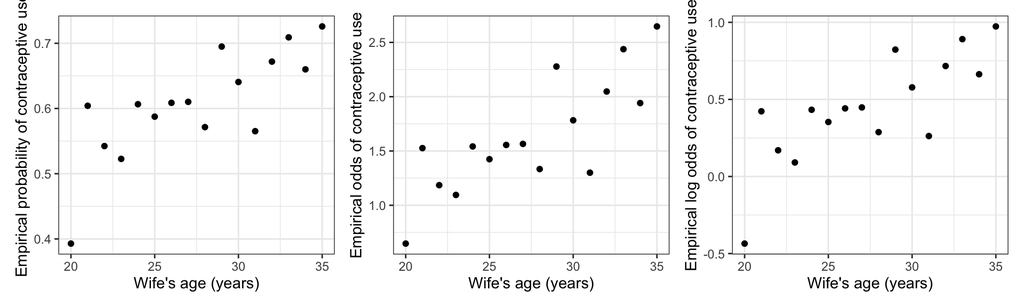

5. True or false: if the log odds are an increasing function of $X$, then the probability is also an increasing function of $X$.

Looking at the scatterplots, all three appear roughly linear. However, logistic regression models the log odds as a linear function of the predictor:

$\log \left( \dfrac{\pi}{1 - \pi} \right) = \beta_0 + \beta_1 \text{Age}$

6. In general, why is it not appropriate to model the probability, or the odds, as a linear function of the predictor?